# R Notebook

```r
library(tmaptools)
library(RColorBrewer)
library(OpenStreetMap)
library(sp)
library(classInt)
library(rgeos)
library(tmap)
library(tmaptools)
library(sf)
library(rgdal)
library(geojsonio)
library(readr)
library(tidyverse)
```

katevazw shp file apo web.

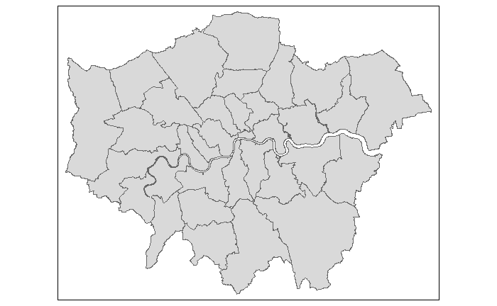

thelw na kratisw mono ta boroughs tou londinou. tsekarw an diavase kala to eng.bound. (to xarti olo tis agglias) metonomazw ta columns gia evkolia. ftiaxnw londonmap, pou krataei mono ta rows sta opoia to column code ksekinaei me e09

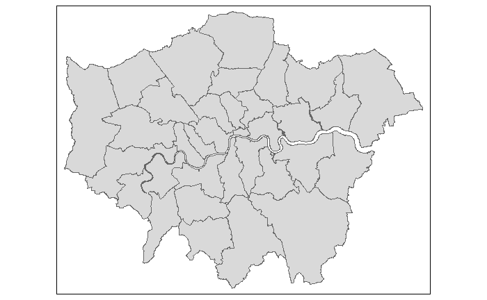

PART 2 etoimazw map me enterprises in London!! anoigw, diavazw, metonomazw k krataw mono ta rows poy thelw(diladi avta gia ta boroughs)

PART 3 kanw join to london_data kai london_map me vasi to koino column !!

```r
class(London_data)
```

```
[1] "data.frame"
```

```r
class(LondonMap)
```

```
[1] "sf"         "data.frame"
```

```r
enterprises_map <- append_data(LondonMap,London_data,key.shp="code",key.data="code1",ignore.duplicates = TRUE)
```

```
Keys match perfectly.
```

```r
class(enterprises_map)
```

```
[1] "sf"         "data.frame"
```

```r
tmap_mode("plot")
```

```
tmap mode set to plotting
```

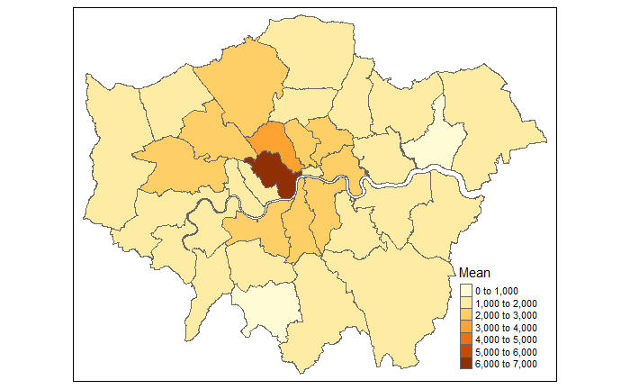

```r
qtm(enterprises_map,fill="Mean")
```

PART 4 MAPPING POLLA MAPS

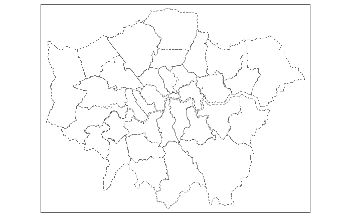

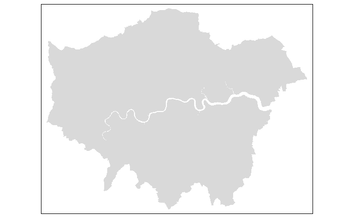

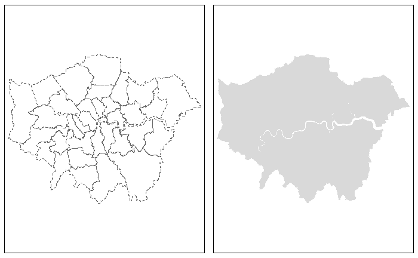

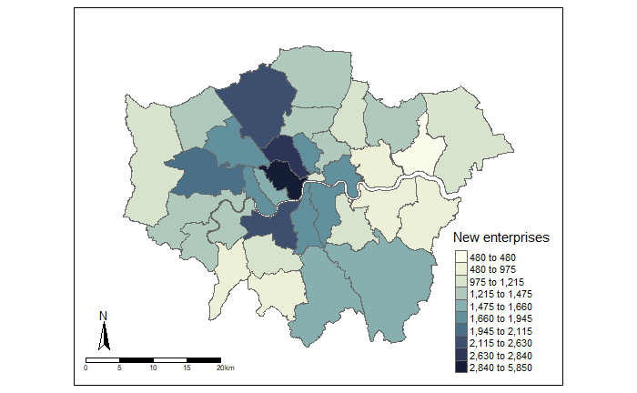

```r
library(reshape2)
library(dplyr)
london_melt <- melt(business_original,id.vars = 1:2, measure.vars = c(3,7,11,15))
london_melt <- left_join(london_melt,LondonMap,by = c("code1" = "code"))
```

```
Column `code1`/`code` joining factors with different levels, coercing to character vector
```

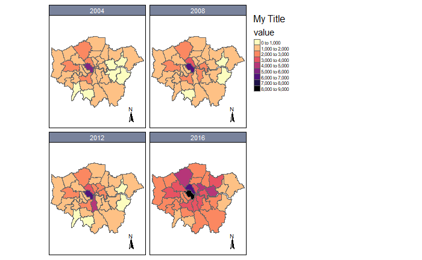

```r
london_melt <- london_melt[,c(1:4,10)]
library(tmap)
library(sf)
london_melt <- london_melt[grep("^E09",london_melt$code1),]
london_melt <- st_as_sf(london_melt)
#tmap_mode("plot")
#qtm(london_melt, fill = "value", by = "variable")
#timeline=tm_shape(london_melt) +tm_facets(by = "variable", nrow = 3, free.coords = FALSE)+ tm_polygons("value", palette="Blues",n=10)+tm_fill("value")
a=tm_shape(london_melt) +
    tm_polygons("value", palette = "-magma",n=8) +
    tm_facets(by = "variable")+tm_layout(panel.labels = c('2004','2008','2012','2016'), panel.label.color = 'white',panel.label.size = 1,panel.label.bg.color = '#79839c',legend.show = TRUE, legend.text.size = 0.5,title="My Title", title.size=1)+tm_compass(type="arrow",size=1.5,fontsize = 0.8)
print(a)
```

ALTERNATIVE (ggplot)

[figure not shown]

```r
install.packages("ggplot2")
library("ggplot2")

palette1<-scale_fill_continuous(low="white", high="orange", "New Enterprises")

labels<-labs(list(title="Number of new Enterprises",x="Longitude", y="Latitude"))

#ggplot()+geom_sf(mapping = aes(geometry=geometry, fill=value),data = london_melt)+theme_minimal()+palette1+labels

#ggplot()+geom_sf(mapping = aes(geometry=geometry,fill=value),data = london_melt)+labs(x="", y="", title="New Enterprises in London")+facet_grid(.~variable)+theme(strip.text.x= element_text(size=8, angle=0),strip.background = element_rect(colour="#CCCCFF", fill="#CCCCFF"),axis.ticks = element_blank())

palette1<-scale_fill_continuous(low="white", high="#c51b8a","Number",limits=c(0, 10000),space="Lab")


palette2 <- scale_fill_gradient2(low = "#cbff23", mid = "#f8ff8c",
  high = "#003bae",
  na.value = "grey50", guide = "colourbar", aesthetics = "fill","New Enterprises in London")

ggplot()+geom_sf(mapping = aes(geometry=geometry,fill=value),data = london_melt)+facet_grid(.~variable)+theme(axis.text.x = element_blank(),axis.text.y = element_blank(),axis.ticks = element_blank(),strip.text.x= element_text(size=8, angle=0),strip.background = element_rect(colour="#CCCCFF", fill="white"))+palette2
```

```r
labels <- c(X2004 = "2004", X2008 = "2008",X2012="2012",X2016="2016")
a <- ggplot()+geom_sf(mapping = aes(geometry=geometry,fill=value),data = london_melt)+facet_wrap(~ variable, ncol = 2,labeller=labeller(variable = labels))+theme1+ggtitle("New enterprises in London, by Borough")+palette2+labs(caption = "Source: Office for National Statistics")

#an to kanw etsi meta den dexetai to North
#g <- grid.arrange(a,bottom = textGrob("Data sources:", x = 1,hjust = 1, gp = gpar(fontface = 3L, fontsize = 9)))
print(a)

pdf(file="mapping_enterprises.pdf",width=10.5,height=8)
north2(a, x = 0.80, y = 0.3, scale = 0.1, symbol = 1)
```

[output not shown]

an thelw na min exei to grid theme2 <- theme(axis.text.x = element_blank(),axis.text.y = element_blank(),axis.ticks = element_blank(),strip.text.x= element_text(size=8, angle=0),strip.background = element_rect(colour=“#CCCCFF”, fill=“white”),legend.background = element_rect(fill=“white”,size=0.5, linetype=“solid”,colour =“darkblue”),legend.position=“right”,legend.box.margin=margin(c(50,50,50,50)))

GIA CAPTION+2 FOOTNOTES g <- grid.arrange(a + labs(caption=“Source:”),bottom = textGrob(“grid caption”, x = 1,hjust = 1, gp = gpar(fontface = 3L, fontsize = 9)))